# Commercial Goals: Unique Member Receipts Logged Seasonal Trends

Reviewing Seasonal Variation

Insights and Analytics | Last Updated: 10 February, 2022

# Top Line

We have provided historical trends for the past few years. The business owner for this metric will ultimately set where were they want the business goal to land.

For the members logging receipt seasonal trends, we have presented the count of unique customer id’s for members who have logged a receipt within that calendar year.

**NOTE:** This metric is only applicable to the yearly time horizon. It is possible that a member could log many receipts throughout a year or a member could log a single receipt. These types of member activity are counted equally by this metric.

Count of Unique Customer ID's By Year

With at least 1 logged receipt for that year

|  | Unique Customers |
| --- | --- |
| 2016 | 178.0K |
| 2017 | 204.8K |
| 2018 | 223.7K |
| 2019 | 194.3K |
| 2020 | 154.4K |
| 2021 | 167.1K |

# Reviewing Historical Data

## Overview of Data

For this analysis we have focused on analyzing the unique customers by day who have logged a receipt in the same month as their purchase date (note items purchased near the end of the month are less likely to be captured as there is a smaller time frame to log a receipt than those purchased at the start of the month).

We have focused on unique customers as they would be a foundational unit for this program (more unique customers would lead to more receipts and increase the likelihood of more total dollars captured).

### Data Generation

Receipts as logged with TangStats. Note that we are only counting “approved” receipts and receipts that are logged in the same month as the purchase date.

### Data Pull from DB

**Source:** TangStats (server: appsql-prod.database.windows.net)

**Tables:** [dbo].[tblReceiptTracking]

- Analyzing receipts that were logged in the same month as the purchase date.
- Records with receipts that were larger than $100,000 were removed

## Monthly Counts

Each point represents the count of members where the first logged receipt was present in that month.

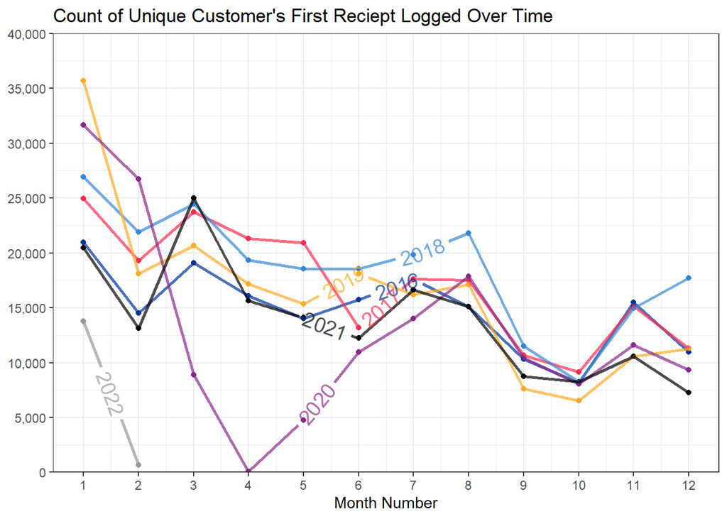

### Monthly Percentages

Each point represents the percent of members where the first logged receipt was present in that month.

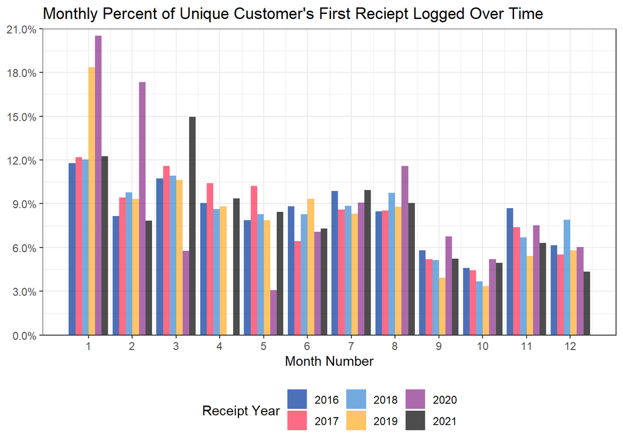

# Appendix

## SQL: Receipts

```sql
Select CustomerID, CenterID, TentID, CreatedOn, PurchaseDate, ReceiptAmount, MinsBtwnPurchAndSubmit
    From (
        Select *
            , datediff(minute, PurchaseDate, CreatedOn) as MinsBtwnPurchAndSubmit
        From tblReceiptTracking
        Where Status = 'A'
            And DeletedOn is null
            And TentID != 'TCPTS'
            And TentID is not null
            And TentID != 'OTHER'
            And ReceiptAmount < 100000
    ) a
```

## Forecast Model

No forecast model was used to generate this data.